# Dada2 tutorial

#chargement dada2package

```r
library("dada2")
library("ggplot2")
```

#Définir la variable de chemin pour qu’elle pointe vers le répertoire extrait sur du machine:

```r
path <- "~/MiSeq_SOP" # CHANGE ME to the directory containing the fastq files after unzipping.
list.files(path)
```

```
 [1] "F3D0_S188_L001_R1_001.fastq"   "F3D0_S188_L001_R2_001.fastq"   "F3D1_S189_L001_R1_001.fastq"
 [4] "F3D1_S189_L001_R2_001.fastq"   "F3D141_S207_L001_R1_001.fastq" "F3D141_S207_L001_R2_001.fastq"
 [7] "F3D142_S208_L001_R1_001.fastq" "F3D142_S208_L001_R2_001.fastq" "F3D143_S209_L001_R1_001.fastq"
[10] "F3D143_S209_L001_R2_001.fastq" "F3D144_S210_L001_R1_001.fastq" "F3D144_S210_L001_R2_001.fastq"
[13] "F3D145_S211_L001_R1_001.fastq" "F3D145_S211_L001_R2_001.fastq" "F3D146_S212_L001_R1_001.fastq"
[16] "F3D146_S212_L001_R2_001.fastq" "F3D147_S213_L001_R1_001.fastq" "F3D147_S213_L001_R2_001.fastq"
[19] "F3D148_S214_L001_R1_001.fastq" "F3D148_S214_L001_R2_001.fastq" "F3D149_S215_L001_R1_001.fastq"
[22] "F3D149_S215_L001_R2_001.fastq" "F3D150_S216_L001_R1_001.fastq" "F3D150_S216_L001_R2_001.fastq"
[25] "F3D2_S190_L001_R1_001.fastq"   "F3D2_S190_L001_R2_001.fastq"   "F3D3_S191_L001_R1_001.fastq"
[28] "F3D3_S191_L001_R2_001.fastq"   "F3D5_S193_L001_R1_001.fastq"   "F3D5_S193_L001_R2_001.fastq"
[31] "F3D6_S194_L001_R1_001.fastq"   "F3D6_S194_L001_R2_001.fastq"   "F3D7_S195_L001_R1_001.fastq"
[34] "F3D7_S195_L001_R2_001.fastq"   "F3D8_S196_L001_R1_001.fastq"   "F3D8_S196_L001_R2_001.fastq"
[37] "F3D9_S197_L001_R1_001.fastq"   "F3D9_S197_L001_R2_001.fastq"   "filtered"
[40] "HMP_MOCK.v35.fasta"            "Mock_S280_L001_R1_001.fastq"   "Mock_S280_L001_R2_001.fastq"
[43] "mouse.dpw.metadata"            "mouse.time.design"             "stability.batch"
[46] "stability.files"
```

#lire les noms des fichiers fastq et effectuer quelques manipulations de chaînes pour obtenir des listes correspondantes des fichiers fastq avant et arrière.

```r
# Forward and reverse fastq filenames have format: SAMPLENAME_R1_001.fastq and SAMPLENAME_R2_001.fastq
fnFs <- sort(list.files(path, pattern="_R1_001.fastq", full.names = TRUE))
fnRs <- sort(list.files(path, pattern="_R2_001.fastq", full.names = TRUE))
# Extract sample names, assuming filenames have format: SAMPLENAME_XXX.fastq
sample.names <- sapply(strsplit(basename(fnFs), "_"), `[`, 1)
```

#Visualiser les profils de qualité des lectures avant:

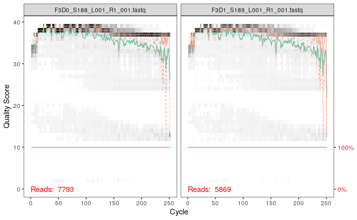

```r
plotQualityProfile(fnFs[1:2])
```

En échelle de gris, une carte thermique de la fréquence de chaque score de qualité à chaque position de base. Le score de qualité moyen à chaque position est indiqué par la ligne verte et les quartiles de la distribution du score de qualité par les lignes orange. La ligne rouge montre la proportion mise à l’échelle des lectures qui s’étendent au moins jusqu’à cette position (ceci est plus utile pour les autres technologies de séquençage, car les lectures Illumina ont généralement la même longueur, d’où la ligne rouge plate).

Les lectures avant sont de bonne qualité. Nous conseillons généralement de rogner les derniers nucléotides pour éviter des erreurs moins bien contrôlées qui peuvent s’y produire. Ces profils de qualité ne suggèrent pas qu’un rognage supplémentaire soit nécessaire. Nous tronquerons les lectures avant à la position 240 (en coupant les 10 derniers nucléotides)

#visualiser le profil de qualité des lectures inversées

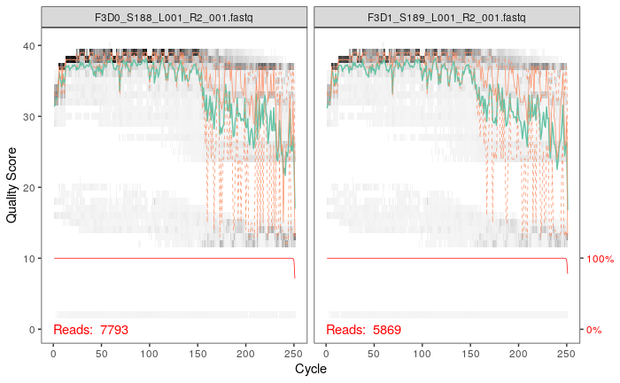

```r
plotQualityProfile(fnRs[1:2])
```

Les lectures inversées sont de qualité nettement moins bonne, en particulier à la fin, ce qui est courant dans le séquençage Illumina. Ce n’est pas trop inquiétant, car DADA2 intègre des informations de qualité dans son modèle d’erreur, ce qui rend l’algorithme robuste à une séquence de qualité inférieure , mais le découpage lorsque les qualités moyennes s’effondrent améliorera la sensibilité de l’algorithme aux variantes de séquence rares. Sur la base de ces profils, nous tronquerons les lectures inversées à la position 160 où la distribution de qualité se bloque

#Attribuez les noms de fichiers aux fichiers fastq.gz filtrés.

```r
# Place filtered files in filtered/ subdirectory
filtFs <- file.path(path, "filtered", paste0(sample.names, "_F_filt.fastq.gz"))
filtRs <- file.path(path, "filtered", paste0(sample.names, "_R_filt.fastq.gz"))
names(filtFs) <- sample.names
names(filtRs) <- sample.names
```

les paramètres de filtrage standard: maxN=0(DADA2 ne nécessite aucun Ns) truncQ=2, rm.phix=TRUEet maxEE=2. Le maxEEparamètre définit le nombre maximum d ’«erreurs attendues» autorisées dans une lecture, ce qui est un meilleur filtre que la simple moyenne des scores de qualité .

```r
out <- filterAndTrim(fnFs, filtFs, fnRs, filtRs, truncLen=c(240,160),
              maxN=0, maxEE=c(2,2), truncQ=2, rm.phix=TRUE,
              compress=TRUE, multithread=TRUE) # On Windows set multithread=FALSE
head(out)
```

```
                              reads.in reads.out
F3D0_S188_L001_R1_001.fastq       7793      7113
F3D1_S189_L001_R1_001.fastq       5869      5299
F3D141_S207_L001_R1_001.fastq     5958      5463
F3D142_S208_L001_R1_001.fastq     3183      2914
F3D143_S209_L001_R1_001.fastq     3178      2941
F3D144_S210_L001_R1_001.fastq     4827      4312
```

#Apprentissage des erreurs dada2 calcul un model d’erreur à partir des données, en alternant l’estimation des taux d’erreur et l’inférence de la composition de l’échantillon jusqu’à ce qu’ils convergent vers une solution cohérente conjointement.

```r
errF <- learnErrors(filtFs, multithread=TRUE)
```

```
33514080 total bases in 139642 reads from 20 samples will be used for learning the error rates.
```

```r
errR <- learnErrors(filtRs, multithread=TRUE)
```

```
22342720 total bases in 139642 reads from 20 samples will be used for learning the error rates.
```

#Vérifier si rien d’autre, de visualiser les taux d’erreur estimés

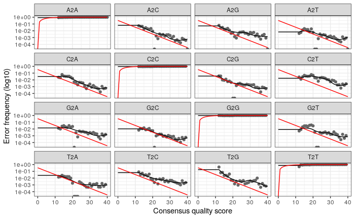

```r
plotErrors(errF, nominalQ=TRUE)
```

Les points sont les taux d’erreur observés pour chaque score de qualité consensuel. La ligne noire montre les taux d’erreur estimés après convergence de l’algorithme d’apprentissage automatique. La ligne rouge montre les taux d’erreur attendus selon la définition nominale du Q-score. Ici, les taux d’erreur estimés (ligne noire) correspondent bien aux taux observés (points), et les taux d’erreur diminuent avec une qualité accrue comme prévu. Tout semble raisonnable et nous procédons en toute confiance

#Inférence d’échantillon

##appliquer l’algorithme d’inférence de l’échantillon de base aux données de séquence filtrées et découpées.

```r
dadaFs <- dada(filtFs, err=errF, multithread=TRUE)
```

```
Sample 1 - 7113 reads in 1979 unique sequences.
Sample 2 - 5299 reads in 1639 unique sequences.
Sample 3 - 5463 reads in 1477 unique sequences.
Sample 4 - 2914 reads in 904 unique sequences.
Sample 5 - 2941 reads in 939 unique sequences.
Sample 6 - 4312 reads in 1267 unique sequences.
Sample 7 - 6741 reads in 1756 unique sequences.
Sample 8 - 4560 reads in 1438 unique sequences.
Sample 9 - 15637 reads in 3590 unique sequences.
Sample 10 - 11413 reads in 2762 unique sequences.
Sample 11 - 12017 reads in 3021 unique sequences.
Sample 12 - 5032 reads in 1566 unique sequences.
Sample 13 - 18075 reads in 3707 unique sequences.
Sample 14 - 6250 reads in 1479 unique sequences.
Sample 15 - 4052 reads in 1195 unique sequences.
Sample 16 - 7369 reads in 1832 unique sequences.
Sample 17 - 4765 reads in 1183 unique sequences.
Sample 18 - 4871 reads in 1382 unique sequences.
Sample 19 - 6504 reads in 1709 unique sequences.
Sample 20 - 4314 reads in 897 unique sequences.
```

```r
dadaRs <- dada(filtRs, err=errR, multithread=TRUE)
```

```
Sample 1 - 7113 reads in 1660 unique sequences.
Sample 2 - 5299 reads in 1349 unique sequences.
Sample 3 - 5463 reads in 1335 unique sequences.
Sample 4 - 2914 reads in 853 unique sequences.
Sample 5 - 2941 reads in 880 unique sequences.
Sample 6 - 4312 reads in 1286 unique sequences.
Sample 7 - 6741 reads in 1803 unique sequences.
Sample 8 - 4560 reads in 1265 unique sequences.
Sample 9 - 15637 reads in 3414 unique sequences.
Sample 10 - 11413 reads in 2522 unique sequences.
Sample 11 - 12017 reads in 2771 unique sequences.
Sample 12 - 5032 reads in 1415 unique sequences.
Sample 13 - 18075 reads in 3290 unique sequences.
Sample 14 - 6250 reads in 1390 unique sequences.
Sample 15 - 4052 reads in 1134 unique sequences.
Sample 16 - 7369 reads in 1635 unique sequences.
Sample 17 - 4765 reads in 1084 unique sequences.
Sample 18 - 4871 reads in 1161 unique sequences.
Sample 19 - 6504 reads in 1502 unique sequences.
Sample 20 - 4314 reads in 732 unique sequences.
```

#Inspecter de l’ dada-classobjet retourné